# Wiederholung

ses

7/1/2021

# 1 Vorbereitung

## 1.1 Pakete laden

```r
library(tidyverse)  # Datenjudo
library(modelr)  # add_predictions
library(skimr)  # viele Statistiken auf einen Happs
library(GGally)  # viele Streudiagramme auf einmal
library(corrr)  # correlate, shave, rplot
library(fastDummies)  # dummyisieren
```

## 1.2 Daten laden

```r
data("diamonds")
```

# 2 Aufgaben

## 2.1 Werte zuweisen

### 2.1.1 Problem

1. Definieren Sie eine Variable “alter” mit dem Wert 42
2. Definieren Sie eine Variable “name” mit dem Wert “Schorsch”
3. Definieren Sie eine Variable “schorsch” mit dem Wert “42”

### 2.1.2 Lösung

```r
alter <- 42  # a
name <- "Schorsch"  # b
schorsch <- "42"  # c
```

```r
name <- schorsch
```

## 2.2 Filtern

### 2.2.1 Problem

Laden Sie zunächst die Tabelle “diamonds”.

Filtern Sie …

1. alle Diamanten besten Schliffs.
2. alle Diamanten mit einem Preis zwischen 1000 und 10000 Dollar.
3. alle Diamanten mit bester Farbe und bestem Schliff
4. die 10% teuersten Diamanten.

### 2.2.2 Lösung

```r
data("diamonds")  # ggplot2, das ist Teil des Tidyverse
```

```r
diamonds %>%
  filter(cut == "Ideal")
```

```
## # A tibble: 21,551 x 10
##    carat cut   color clarity depth table price     x     y     z
##    <dbl> <ord> <ord> <ord>   <dbl> <dbl> <int> <dbl> <dbl> <dbl>
##  1  0.23 Ideal E     SI2      61.5    55   326  3.95  3.98  2.43
##  2  0.23 Ideal J     VS1      62.8    56   340  3.93  3.9   2.46
##  3  0.31 Ideal J     SI2      62.2    54   344  4.35  4.37  2.71
##  4  0.3  Ideal I     SI2      62      54   348  4.31  4.34  2.68
##  5  0.33 Ideal I     SI2      61.8    55   403  4.49  4.51  2.78
##  6  0.33 Ideal I     SI2      61.2    56   403  4.49  4.5   2.75
##  7  0.33 Ideal J     SI1      61.1    56   403  4.49  4.55  2.76
##  8  0.23 Ideal G     VS1      61.9    54   404  3.93  3.95  2.44
##  9  0.32 Ideal I     SI1      60.9    55   404  4.45  4.48  2.72
## 10  0.3  Ideal I     SI2      61      59   405  4.3   4.33  2.63
## # … with 21,541 more rows
```

alle Diamanten mit einem Preis zwischen 1000 und 10000 Dollar.

```r
diamonds %>%
  filter(price >= 1e3 & price <= 1e4)
```

```
## # A tibble: 34,219 x 10
##    carat cut       color clarity depth table price     x     y     z
##    <dbl> <ord>     <ord> <ord>   <dbl> <dbl> <int> <dbl> <dbl> <dbl>
##  1  0.7  Ideal     E     SI1      62.5    57  2757  5.7   5.72  3.57
##  2  0.86 Fair      E     SI2      55.1    69  2757  6.45  6.33  3.52
##  3  0.7  Ideal     G     VS2      61.6    56  2757  5.7   5.67  3.5
##  4  0.71 Very Good E     VS2      62.4    57  2759  5.68  5.73  3.56
##  5  0.78 Very Good G     SI2      63.8    56  2759  5.81  5.85  3.72
##  6  0.7  Good      E     VS2      57.5    58  2759  5.85  5.9   3.38
##  7  0.7  Good      F     VS1      59.4    62  2759  5.71  5.76  3.4
##  8  0.96 Fair      F     SI2      66.3    62  2759  6.27  5.95  4.07
##  9  0.73 Very Good E     SI1      61.6    59  2760  5.77  5.78  3.56
## 10  0.8  Premium   H     SI1      61.5    58  2760  5.97  5.93  3.66
## # … with 34,209 more rows
```

```r
diamonds %>%
  filter(between(price, 1e03, 1e04))
```

```
## # A tibble: 34,219 x 10
##    carat cut       color clarity depth table price     x     y     z
##    <dbl> <ord>     <ord> <ord>   <dbl> <dbl> <int> <dbl> <dbl> <dbl>
##  1  0.7  Ideal     E     SI1      62.5    57  2757  5.7   5.72  3.57
##  2  0.86 Fair      E     SI2      55.1    69  2757  6.45  6.33  3.52
##  3  0.7  Ideal     G     VS2      61.6    56  2757  5.7   5.67  3.5
##  4  0.71 Very Good E     VS2      62.4    57  2759  5.68  5.73  3.56
##  5  0.78 Very Good G     SI2      63.8    56  2759  5.81  5.85  3.72
##  6  0.7  Good      E     VS2      57.5    58  2759  5.85  5.9   3.38
##  7  0.7  Good      F     VS1      59.4    62  2759  5.71  5.76  3.4
##  8  0.96 Fair      F     SI2      66.3    62  2759  6.27  5.95  4.07
##  9  0.73 Very Good E     SI1      61.6    59  2760  5.77  5.78  3.56
## 10  0.8  Premium   H     SI1      61.5    58  2760  5.97  5.93  3.66
## # … with 34,209 more rows
```

3. alle Diamanten mit bester Farbe und bestem Schliff

```r
diamonds %>%
  filter(cut == "Ideal", color == "D")
```

```
## # A tibble: 2,834 x 10
##    carat cut   color clarity depth table price     x     y     z
##    <dbl> <ord> <ord> <ord>   <dbl> <dbl> <int> <dbl> <dbl> <dbl>
##  1  0.3  Ideal D     SI1      62.5    57   552  4.29  4.32  2.69
##  2  0.3  Ideal D     SI1      62.1    56   552  4.3   4.33  2.68
##  3  0.71 Ideal D     SI2      62.3    56  2762  5.73  5.69  3.56
##  4  0.71 Ideal D     SI1      61.9    59  2764  5.69  5.72  3.53
##  5  0.71 Ideal D     SI2      61.6    55  2767  5.74  5.76  3.54
##  6  0.76 Ideal D     SI2      62.4    57  2770  5.78  5.83  3.62
##  7  0.73 Ideal D     SI2      59.9    57  2770  5.92  5.89  3.54
##  8  0.75 Ideal D     SI2      61.3    56  2773  5.85  5.89  3.6
##  9  0.72 Ideal D     SI1      60.8    57  2782  5.76  5.75  3.5
## 10  0.64 Ideal D     VS1      61.5    56  2787  5.54  5.55  3.41
## # … with 2,824 more rows
```

4. die 10% teuersten Diamanten

```r
diamonds %>%
  slice_max(order_by = price, prop = .1)
```

```
## # A tibble: 5,396 x 10
##    carat cut       color clarity depth table price     x     y     z
##    <dbl> <ord>     <ord> <ord>   <dbl> <dbl> <int> <dbl> <dbl> <dbl>
##  1  2.29 Premium   I     VS2      60.8    60 18823  8.5   8.47  5.16
##  2  2    Very Good G     SI1      63.5    56 18818  7.9   7.97  5.04
##  3  1.51 Ideal     G     IF       61.7    55 18806  7.37  7.41  4.56
##  4  2.07 Ideal     G     SI2      62.5    55 18804  8.2   8.13  5.11
##  5  2    Very Good H     SI1      62.8    57 18803  7.95  8     5.01
##  6  2.29 Premium   I     SI1      61.8    59 18797  8.52  8.45  5.24
##  7  2.04 Premium   H     SI1      58.1    60 18795  8.37  8.28  4.84
##  8  2    Premium   I     VS1      60.8    59 18795  8.13  8.02  4.91
##  9  1.71 Premium   F     VS2      62.3    59 18791  7.57  7.53  4.7
## 10  2.15 Ideal     G     SI2      62.6    54 18791  8.29  8.35  5.21
## # … with 5,386 more rows
```

```r
d2 <- diamonds %>%
  mutate(price_percent = percent_rank(price)) %>%
  filter(price_percent > .9)

d2
```

```
## # A tibble: 5,393 x 11
##    carat cut     color clarity depth table price     x     y     z price_percent
##    <dbl> <ord>   <ord> <ord>   <dbl> <dbl> <int> <dbl> <dbl> <dbl>         <dbl>
##  1  1.53 Very G… I     VS1      59.3    58  9823  7.5   7.54  4.46         0.900
##  2  3.11 Fair    J     I1       65.9    57  9823  9.15  9.02  5.98         0.900
##  3  1.5  Ideal   I     VS2      60      61  9827  7.39  7.42  4.44         0.900
##  4  1.5  Very G… I     VVS2     63.3    58  9828  7.24  7.21  4.57         0.900
##  5  1.5  Good    I     VS1      57.9    60  9828  7.48  7.44  4.32         0.900
##  6  1.5  Ideal   E     SI1      61.9    57  9828  7.37  7.31  4.54         0.900
##  7  1.5  Premium I     VS1      61.6    59  9828  7.32  7.26  4.49         0.900
##  8  1.52 Premium E     SI2      58.1    60  9831  7.59  7.53  4.39         0.900
##  9  1.08 Ideal   G     IF       62.3    56  9831  6.55  6.59  4.09         0.900
## 10  1.51 Ideal   H     SI1      61.3    56  9833  7.4   7.44  4.55         0.900
## # … with 5,383 more rows
```

## 2.3 Zusammenfassen

### 2.3.1 Problem

1. Was ist der mittlere Preis der Diamanten?
2. Der mediane?
3. die SD?
4. der IQR?
5. Was lernen wir daraus, wenn es zwischen Median und MW einen Unterschied gibt?
6. Kennen Sie einen Weg, viele Statistiken auf einmal zu bekommen? Welchen?
7. Was ist der mittlere Preis pro Stufe von `cut`?

### 2.3.2 Lösung

1. Was ist der mittlere Preis der Diamanten?

```r
diamonds %>%
  drop_na(price) %>%
  summarise(price_m = mean(price))
```

```
## # A tibble: 1 x 1
##   price_m
##     <dbl>
## 1   3933.
```

2. Der mediane?

```r
diamonds %>%
  drop_na(price) %>%
  summarise(price_md = median(price))
```

```
## # A tibble: 1 x 1
##   price_md
##      <dbl>
## 1     2401
```

3. und d)

```r
diamonds %>%
  drop_na(price) %>%
  summarise(price_sd = sd(price),
            price_iqr = IQR(price))
```

```
## # A tibble: 1 x 2
##   price_sd price_iqr
##      <dbl>     <dbl>
## 1    3989.     4374.
```

5. Was lernen wir daraus, wenn es zwischen Median und MW einen Unterschied gibt?

MW - Md ist prop. zur Schiefe (es gibt Extremwerte)

6. Kennen Sie einen Weg, viele Statistiken auf einmal zu bekommen? Welchen?

```r
library(skimr)

skim(diamonds)
```

Data summary

| Name | diamonds |
| --- | --- |
| Number of rows | 53940 |
| Number of columns | 10 |
| _______________________ |  |
| Column type frequency: |  |
| factor | 3 |
| numeric | 7 |
| ________________________ |  |
| Group variables | None |

**Variable type: factor**

| skim_variable | n_missing | complete_rate | ordered | n_unique | top_counts |
| --- | --- | --- | --- | --- | --- |
| cut | 0 | 1 | TRUE | 5 | Ide: 21551, Pre: 13791, Ver: 12082, Goo: 4906 |
| color | 0 | 1 | TRUE | 7 | G: 11292, E: 9797, F: 9542, H: 8304 |
| clarity | 0 | 1 | TRUE | 8 | SI1: 13065, VS2: 12258, SI2: 9194, VS1: 8171 |

**Variable type: numeric**

| skim_variable | n_missing | complete_rate | mean | sd | p0 | p25 | p50 | p75 | p100 | hist |
| --- | --- | --- | --- | --- | --- | --- | --- | --- | --- | --- |
| carat | 0 | 1 | 0.80 | 0.47 | 0.2 | 0.40 | 0.70 | 1.04 | 5.01 | ▇▂▁▁▁ |
| depth | 0 | 1 | 61.75 | 1.43 | 43.0 | 61.00 | 61.80 | 62.50 | 79.00 | ▁▁▇▁▁ |
| table | 0 | 1 | 57.46 | 2.23 | 43.0 | 56.00 | 57.00 | 59.00 | 95.00 | ▁▇▁▁▁ |
| price | 0 | 1 | 3932.80 | 3989.44 | 326.0 | 950.00 | 2401.00 | 5324.25 | 18823.00 | ▇▂▁▁▁ |
| x | 0 | 1 | 5.73 | 1.12 | 0.0 | 4.71 | 5.70 | 6.54 | 10.74 | ▁▁▇▃▁ |
| y | 0 | 1 | 5.73 | 1.14 | 0.0 | 4.72 | 5.71 | 6.54 | 58.90 | ▇▁▁▁▁ |
| z | 0 | 1 | 3.54 | 0.71 | 0.0 | 2.91 | 3.53 | 4.04 | 31.80 | ▇▁▁▁▁ |

7. Was ist der mittlere Preis pro Stufe von `cut`?

```r
diamonds %>%
  group_by(cut) %>%
  summarise(price_avg = mean(price))
```

```
## # A tibble: 5 x 2
##   cut       price_avg
##   <ord>         <dbl>
## 1 Fair          4359.
## 2 Good          3929.
## 3 Very Good     3982.
## 4 Premium       4584.
## 5 Ideal         3458.
```

## 2.4 Sortieren

### 2.4.1 Problem

Sortieren Sie den Datensatz nach Preis und zeigen Sie die Top-3-Diamanten (hinsichtlich der max. Höhe des Preises)!

### 2.4.2 Lösung

```r
diamonds %>%
  arrange(-price) %>%   # alternativ: desc(price)
  slice(1:3)
```

```
## # A tibble: 3 x 10
##   carat cut       color clarity depth table price     x     y     z
##   <dbl> <ord>     <ord> <ord>   <dbl> <dbl> <int> <dbl> <dbl> <dbl>
## 1  2.29 Premium   I     VS2      60.8    60 18823  8.5   8.47  5.16
## 2  2    Very Good G     SI1      63.5    56 18818  7.9   7.97  5.04
## 3  1.51 Ideal     G     IF       61.7    55 18806  7.37  7.41  4.56
```

```r
diamonds %>%
  slice_max(price, n = 3)
```

```
## # A tibble: 3 x 10
##   carat cut       color clarity depth table price     x     y     z
##   <dbl> <ord>     <ord> <ord>   <dbl> <dbl> <int> <dbl> <dbl> <dbl>
## 1  2.29 Premium   I     VS2      60.8    60 18823  8.5   8.47  5.16
## 2  2    Very Good G     SI1      63.5    56 18818  7.9   7.97  5.04
## 3  1.51 Ideal     G     IF       61.7    55 18806  7.37  7.41  4.56
```

## 2.5 Mutieren

### 2.5.1 Problem

1. Erstellen Sie eine Variable, die die *Größenordnung* des Preises angibt:
- dreistelliger Preis (100-999) -> Wert ist *2* -> log10(100) = 2
- vierstelliger Preis (1000-9999) -> Wert ist *3*
- etc.
2. Berechnen Sie eine Art “Volumen” des Diamanten, in dem Sie `x`, `y` und `z` multiplizieren.
3. Erstellen Sie eine Variable, die angibt, ob der Preis des Diamanten größer als der Mittelwert ist.
4. Berechnen Sie die Korrelation von Volumen und Gewicht (`carat`).

### 2.5.2 Lösung

```r
log10(100) == 2
```

```
## [1] TRUE
```

```r
log10(1000) == 3
```

```
## [1] TRUE
```

```r
log10(1e4) == 4  # 10000 = 10^4
```

```
## [1] TRUE
```

:-)

```r
diamonds <-
  diamonds %>%
  mutate(preis_log10 = log10(price))
```

In diesem Fall wäre es nicht so gut mit `case_when` zu arbeiten:

```r
diamonds %>%
  mutate(price_oom = case_when(
    price > 100 & price < 1000 ~ 2,
    price < 10000 ~ 3,
    TRUE ~ NA_real_
  ))
```

```
## # A tibble: 53,940 x 12
##    carat cut       color clarity depth table price     x     y     z preis_log10
##    <dbl> <ord>     <ord> <ord>   <dbl> <dbl> <int> <dbl> <dbl> <dbl>       <dbl>
##  1  0.23 Ideal     E     SI2      61.5    55   326  3.95  3.98  2.43        2.51
##  2  0.21 Premium   E     SI1      59.8    61   326  3.89  3.84  2.31        2.51
##  3  0.23 Good      E     VS1      56.9    65   327  4.05  4.07  2.31        2.51
##  4  0.29 Premium   I     VS2      62.4    58   334  4.2   4.23  2.63        2.52
##  5  0.31 Good      J     SI2      63.3    58   335  4.34  4.35  2.75        2.53
##  6  0.24 Very Good J     VVS2     62.8    57   336  3.94  3.96  2.48        2.53
##  7  0.24 Very Good I     VVS1     62.3    57   336  3.95  3.98  2.47        2.53
##  8  0.26 Very Good H     SI1      61.9    55   337  4.07  4.11  2.53        2.53
##  9  0.22 Fair      E     VS2      65.1    61   337  3.87  3.78  2.49        2.53
## 10  0.23 Very Good H     VS1      59.4    61   338  4     4.05  2.39        2.53
## # … with 53,930 more rows, and 1 more variable: price_oom <dbl>
```

```r
diamonds <-
  diamonds %>%
  mutate(volume = x * y * z)
```

```r
diamonds <-
  diamonds %>%
  mutate(price_high = case_when(  # ifelse würde auch gehen
    price > mean(price) ~ TRUE,
    TRUE ~ FALSE
  ))
```

```r
diamonds %>%
  count(price_high)
```

```
## # A tibble: 2 x 2
##   price_high     n
##   <lgl>      <int>
## 1 FALSE      34283
## 2 TRUE       19657
```

```r
diamonds %>%
  select(carat, volume) %>%
  cor()  #Input: Eine Tabelle mit nur numerischen Spalten
```

```
##            carat    volume
## carat  1.0000000 0.9763084
## volume 0.9763084 1.0000000
```

## 2.6 Log-Transformation

### 2.6.1 Problem

1. Welche Hypothese finden Sie am plausibelsten? Begründen Sie!
   - H1: Steigt das Gewicht des Diamanten um 1 Gramm, so steigt der Preis (im Schnitt) um $b$ Dollar?
   - H2: Steigt das Gewicht des Diamanten um 1 Gramm, so steigt der Preis (im Schnitt) um $b$ *Prozent*? (exponenzielles Wachstum)
   - H3: Steigt das Gewicht des Diamanten um 1 *Prozent*, so steigt der Preis (im Schnitt) um $b$ *Prozent*? (Wachstum nach einer Potenzfunktion)
2. Betrachten Sie den Zusammenhang von Preis und Gewicht und prüfen Sie, ob Sie den Zusammenhang durch eine Log-Transformation *linearisieren* können.
3. Vielleicht hilft auch eine andere Art von Transformation (um den Zusammenhang zu linearisieren)? Probieren Sie es aus!

### 2.6.2 Lösung

#### 2.6.2.1 a)

**Hyp.1** : Die Hypothese impliziert, dass der Preiszuwachs von 1 auf 2 Karat zum gleichen Preiszuwachs führt wie die Erhöhung von 2 auf 3 Karat (unter sonst gleichen Umständen).

Die Daten unterstützen das nicht:

```r
diamonds %>%
  mutate(carat_rounded = round(carat)) %>%
  group_by(carat_rounded) %>%
  summarise(mean(price))
```

```
## # A tibble: 6 x 2
##   carat_rounded `mean(price)`
##           <dbl>         <dbl>
## 1             0          840.
## 2             1         4163.
## 3             2        12196.
## 4             3        15369.
## 5             4        15715.
## 6             5        18018
```

Aber bleiben wir für Erste bei einer theoretischen Erörterung.

**Hyp 2**: “Steigt das Gewicht des Diamanten um 1 Gramm, so steigt der Preis (im Schnitt) um $b$ *Prozent*?”

Dieses Wachstumsmuster nennt man auch *exponenzielles* Wachstum und ist sehr häufig bei allen (biologisch) *Wachstumsprozessen*, macht aber hier nicht unbedingt viel Sinn (könnte aber trotzdem die Daten passabel beschreiben, sollten wir gleich mal ausprobieren).

**Hyp3**: “Steigt das Gewicht des Diamanten um 1 *Prozent*, so steigt der Preis (im Schnitt) um $b$ *Prozent*?”

Überlegen wir mal, wie Karat mit dem Preis zusammenhängt. Sachwissen (und eine EDA) zeigt, dass Karat der zentrale Treiber (und Ursache?) des Preises ist. Karat ist ein Form, das Gewicht zu messen: Ein Karat sind 0.2 Gramm. Das Gewicht (Karat; $c$) ist eine Funktion des Volumen und Volumen ist eine Funktion von Länge, Breite und Höhe (x,y,z): $c =f(x,y,z$): $y=x^3$. Potenzfunktion! Einige Momente ruhiges Nachdenken zeigen, dass solche Zusammenhänge eine Potenzfunktion darstellen. Potenzfunktionen haben stets das Wachstumsmuster wie in Hypothese 3 aufgeführt. Diese “Theorie” spricht sich also für die Stichhaltigkeit von Hypothese 3 aus. Das sollten wir gleich mal an den Daten überprüfen!

$y=x^3$

x=1 -> y=1 x=2 -> 2*2*2=8 x=3 -> 3*3*3=27 x=4 -> 4*4*4=64 x=6 -> 6*6*6=216

Verdoppeln wir x, so verachtfachen wir y.

#### 2.6.2.2 b)

Ohne Transformation:

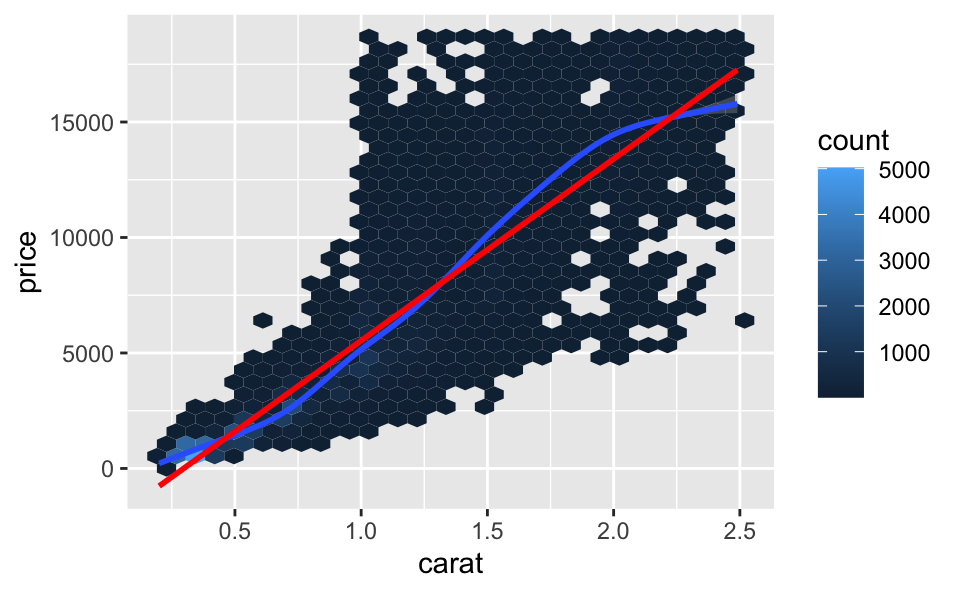

```r
diamonds %>%
  filter(carat < 2.5) %>%  # bleiben >50000 übrig
  ggplot() +
  aes(x = carat, y = price) +
  geom_hex() +
  geom_smooth() +
  geom_smooth(method = "lm", color = "red")
```

Mit Log-Transformation:

exponenzielles Wachstum

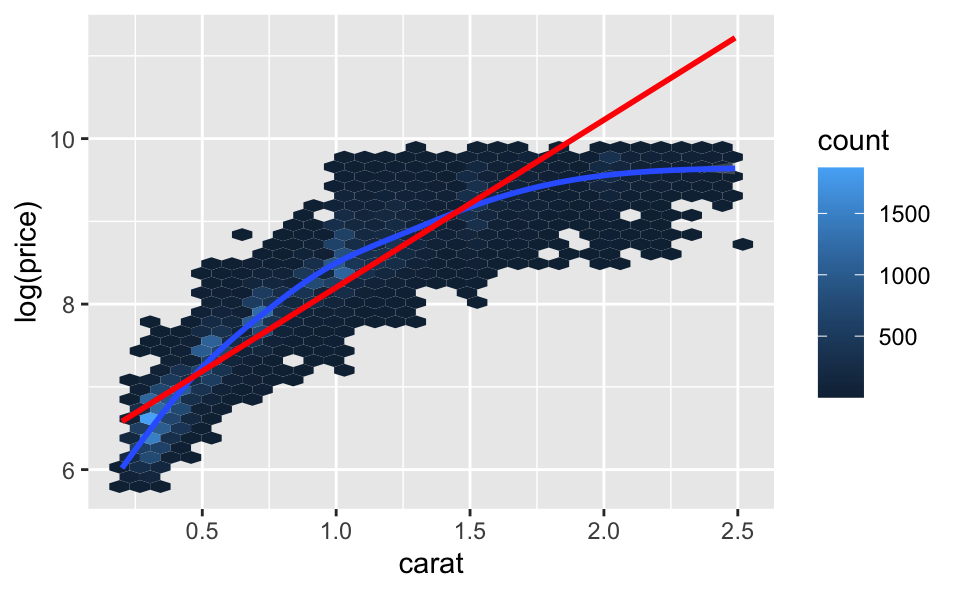

```r
diamonds %>%
  filter(carat < 2.5) %>%
  ggplot() +
  aes(x = carat, y = log(price)) +
  geom_hex() +
  geom_smooth() +
  geom_smooth(method = "lm", color = "red")
```

Potenzfunktion:

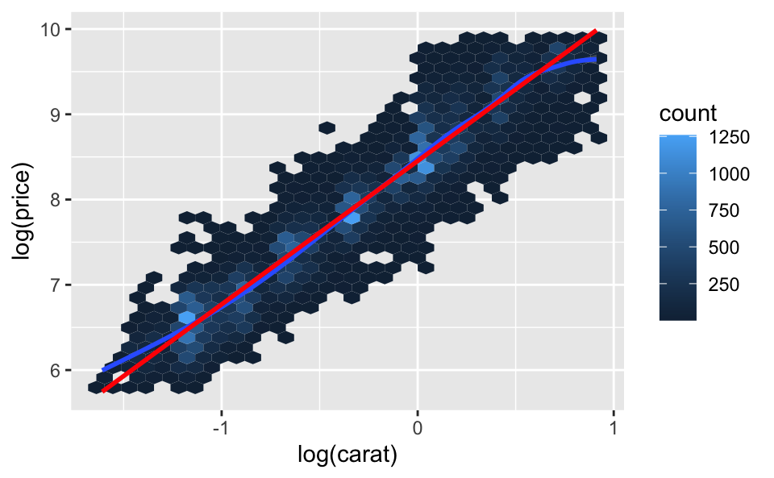

```r
diamonds %>%
  filter(carat < 2.5) %>%
  ggplot() +
  aes(x = log(carat), y = log(price)) +
  geom_hex() +
  geom_smooth() +
  geom_smooth(method = "lm", color = "red")
```

Das sieht super aus! So sollte eine Regression gut funktionieren!

#### 2.6.2.3 c)

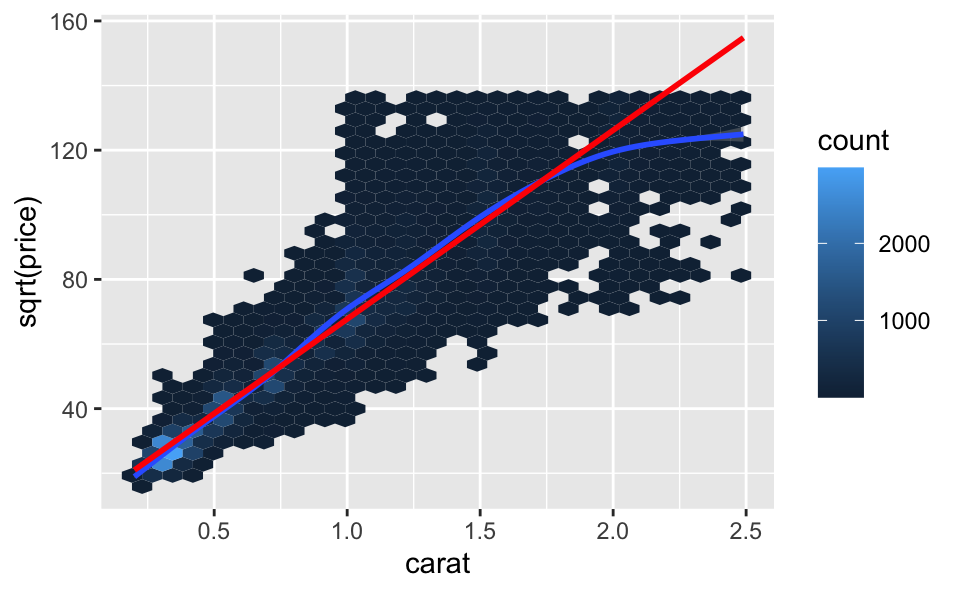

```r
diamonds %>%
  filter(carat < 2.5) %>%
  ggplot() +
  aes(x = carat, y = sqrt(price)) +
  geom_hex() +
  geom_smooth() +
  geom_smooth(method = "lm", color = "red")
```

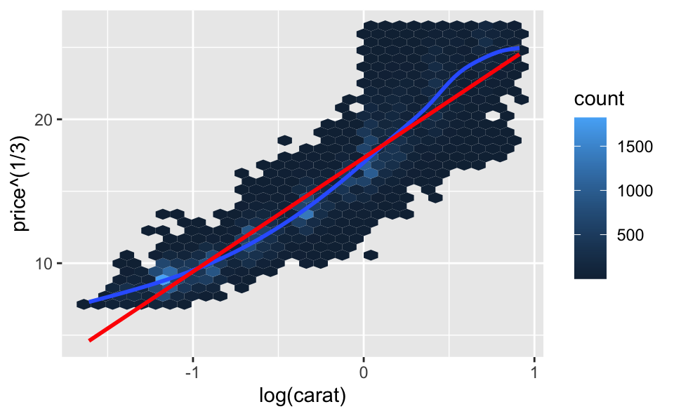

```r
diamonds %>%
  filter(carat < 2.5) %>%
  ggplot() +
  aes(x = log(carat), y = price^(1/3)) +
  geom_hex() +
  geom_smooth() +
  geom_smooth(method = "lm", color = "red")
```

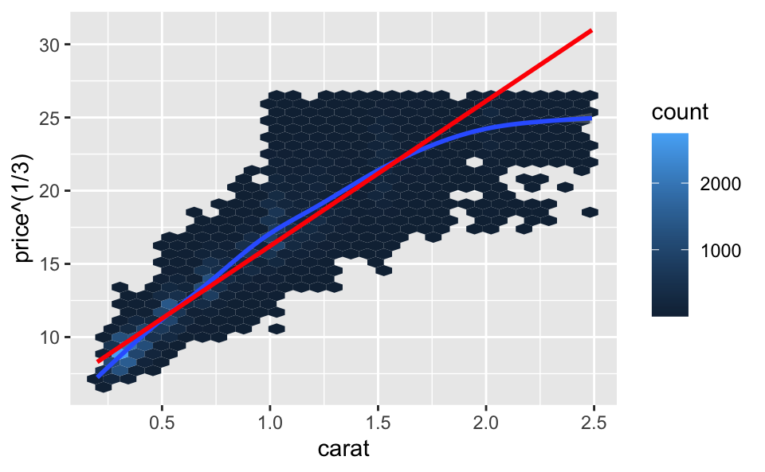

```r
diamonds %>%
  filter(carat < 2.5) %>%
  ggplot() +
  aes(x = carat, y = price^(1/3)) +
  geom_hex() +
  geom_smooth() +
  geom_smooth(method = "lm", color = "red")
```

## 2.7 Regressionsgüte nach Transformationen

Vergleichen Sie die Vorhersagegüte von Modellen, die den Preis anhand des Gewichts vorhersagen.

### 2.7.1 Lösung

```r
lm1 <- lm(price ~ carat, data = diamonds %>% filter(carat < 2.5))
```

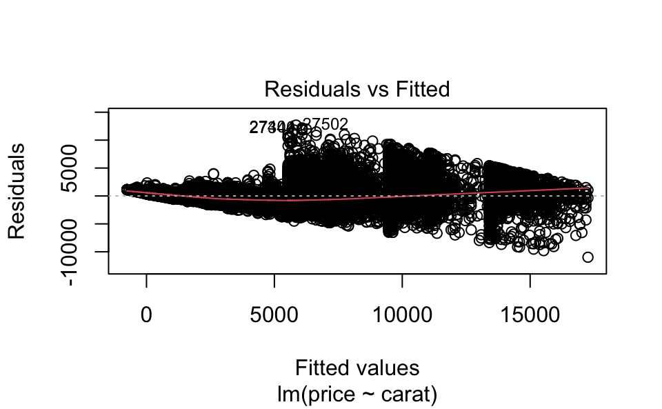

```r
plot(lm1, which = 1)  # ggfortify::autoplot(lm1)
```

```r
summary(lm1)$r.squared
```

```
## [1] 0.8520234
```

Modell mit *exponenziellem* Zusammenhang

```r
lm2 <- lm(log(price) ~ carat, data = diamonds %>% filter(carat != 0))
```

Die Passung der Modellannahmen lässt sich gut grafisch überprüfen:

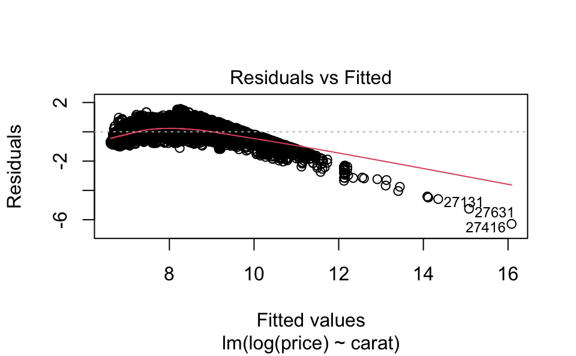

```r
plot(lm2, which = 1)
```

```r
summary(lm2)$r.squared
```

```
## [1] 0.8467802
```

```r
lm3 <- lm(log(price) ~ log(carat), data = diamonds)
```

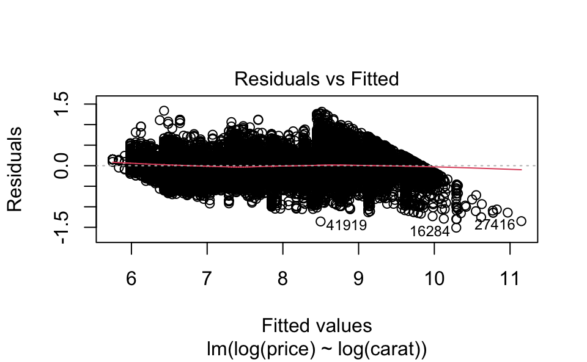

```r
plot(lm3, which = 1)
```

```r
summary(lm3)$r.squared
```

```
## [1] 0.9329893
```

## 2.8 Rücktransformation y-Werte

### 2.8.1 Problem

Sagen Sie die Preise laut Ihrem besten Modell vorher; führen Sie ggf. eine Rücktransformation vorab durch!

### 2.8.2 Lösung

Ohne Rücktransformation:

```r
diamonds %>%
  add_predictions(lm3) %>%  # kommt aus dem Paket `modelr`
  select(price, pred) %>%
  slice(1:6)
```

```
## # A tibble: 6 x 2
##   price  pred
##   <int> <dbl>
## 1   326  5.99
## 2   326  5.83
## 3   327  5.99
## 4   334  6.37
## 5   335  6.49
## 6   336  6.06
```

Mit Rücktransformation:

vorwärts: x -> log

rückwärts: exp(x) -> x

Basis $e$:

```r
e <- 2.7182
x <- 1
exp(log(x)) == 1  # synonym:
```

```
## [1] TRUE
```

```r
e^log(x) == 1
```

```
## [1] TRUE
```

Basis 10:

```r
x <- 3
log10(x)
```

```
## [1] 0.4771213
```

```r
10^log10(x) == x
```

```
## [1] TRUE
```

Das geht mit jeder beliebigen Basis. Wichtige Basen sind e, 10 und 2.

```r
diamonds %>%
  add_predictions(lm3, var = "pred_lm3") %>%  # mit "var" kann man den Namen der neuen Spalte anpassen
  mutate(pred_raw = exp(pred_lm3)) %>%  # Rücktransformation
  select(price, pred_lm3, pred_raw) %>%
  slice(1:6)
```

```
## # A tibble: 6 x 3
##   price pred_lm3 pred_raw
##   <int>    <dbl>    <dbl>
## 1   326     5.99     398.
## 2   326     5.83     341.
## 3   327     5.99     398.
## 4   334     6.37     587.
## 5   335     6.49     656.
## 6   336     6.06     427.
```

wir sind jetzt wieder in der richtigen Größenordnung mit unseren Vorhersagen. Die Rück-Transformation hat also geklappt! Diese Werte würden Sie nun einreichen.

## 2.9 Fehlende Werte zählen

### 2.9.1 Problem

1. Wie viele fehlenden Werte gibt es in der Tabelle?
2. … in der Spalte `price`?
3. … in jeder einzelnen Spalte?

### 2.9.2 Lösung

#### 2.9.2.1 a), b), c)

```r
skim(diamonds)  # package "skimr"
```

Data summary

| Name | diamonds |
| --- | --- |
| Number of rows | 53940 |
| Number of columns | 13 |
| _______________________ |  |
| Column type frequency: |  |
| factor | 3 |
| logical | 1 |
| numeric | 9 |
| ________________________ |  |
| Group variables | None |

**Variable type: factor**

| skim_variable | n_missing | complete_rate | ordered | n_unique | top_counts |
| --- | --- | --- | --- | --- | --- |
| cut | 0 | 1 | TRUE | 5 | Ide: 21551, Pre: 13791, Ver: 12082, Goo: 4906 |
| color | 0 | 1 | TRUE | 7 | G: 11292, E: 9797, F: 9542, H: 8304 |
| clarity | 0 | 1 | TRUE | 8 | SI1: 13065, VS2: 12258, SI2: 9194, VS1: 8171 |

**Variable type: logical**

| skim_variable | n_missing | complete_rate | mean | count |
| --- | --- | --- | --- | --- |
| price_high | 0 | 1 | 0.36 | FAL: 34283, TRU: 19657 |

**Variable type: numeric**

| skim_variable | n_missing | complete_rate | mean | sd | p0 | p25 | p50 | p75 | p100 | hist |
| --- | --- | --- | --- | --- | --- | --- | --- | --- | --- | --- |
| carat | 0 | 1 | 0.80 | 0.47 | 0.20 | 0.40 | 0.70 | 1.04 | 5.01 | ▇▂▁▁▁ |
| depth | 0 | 1 | 61.75 | 1.43 | 43.00 | 61.00 | 61.80 | 62.50 | 79.00 | ▁▁▇▁▁ |
| table | 0 | 1 | 57.46 | 2.23 | 43.00 | 56.00 | 57.00 | 59.00 | 95.00 | ▁▇▁▁▁ |
| price | 0 | 1 | 3932.80 | 3989.44 | 326.00 | 950.00 | 2401.00 | 5324.25 | 18823.00 | ▇▂▁▁▁ |
| x | 0 | 1 | 5.73 | 1.12 | 0.00 | 4.71 | 5.70 | 6.54 | 10.74 | ▁▁▇▃▁ |
| y | 0 | 1 | 5.73 | 1.14 | 0.00 | 4.72 | 5.71 | 6.54 | 58.90 | ▇▁▁▁▁ |
| z | 0 | 1 | 3.54 | 0.71 | 0.00 | 2.91 | 3.53 | 4.04 | 31.80 | ▇▁▁▁▁ |
| preis_log10 | 0 | 1 | 3.38 | 0.44 | 2.51 | 2.98 | 3.38 | 3.73 | 4.27 | ▅▇▇▇▅ |
| volume | 0 | 1 | 129.85 | 78.25 | 0.00 | 65.14 | 114.81 | 170.84 | 3840.60 | ▇▁▁▁▁ |

## 2.10 Korrelationen mit Preis visualisieren

### 2.10.1 Problem

Visualisieren Sie den Zusammenhang von Preis mit den wichtigen Prädiktoren.

### 2.10.2 Lösung

Es gibt viele Pakete, die hier coole Visualisierungen ermöglichen. Hier eine Auswahl; googeln Sie ggf. nach mehr.

```r
diamonds %>%
  # select(where(is.numeric)) %>%   # oder so
  select(price, carat, x, y, z, table, depth) %>%
  correlate() %>%
  shave() %>%
  focus(price)
```

```
## # A tibble: 6 x 2
##   term    price
##   <chr>   <dbl>
## 1 carat  0.922
## 2 x      0.884
## 3 y      0.865
## 4 z      0.861
## 5 table  0.127
## 6 depth -0.0106
```

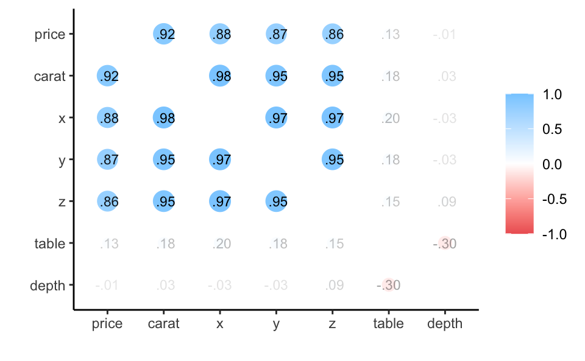

```r
diamonds %>%
  # select(where(is.numeric)) %>%   # oder so
  select(price, carat, x, y, z, table, depth) %>%
  correlate() %>%
  rplot(print_cor = TRUE)
```

[figure not shown]

```r
diamonds %>%
  select(where(is.numeric)) %>%
  ggpairs()
```

#### 2.10.2.1 Vertiefung

Eine Korrelation kann man nur zwischen *numerischen* Variablen berechnen, nicht zwischen nicht-numerischen. Aber man kann *kategoriale* Variablen “*dummysieren*”, dann ist es wieder möglich, eine Korrelation zu berechnen.

cut: A, B, C –>dummysierung

cut_A: 1,0,0 cut_B: 0,1,0 cut_C: 0,0,1 –> ist redundant, aber die Regression macht dann dicke Backen

Das Paket `fastDummies` ermöglicht eine Dummysierung auf recht komfortable Weise.

```r
d2 <-
diamonds %>%
  fastDummies::dummy_cols(select_columns = c("cut", "color", "clarity"),
             remove_selected_columns = TRUE,
             remove_first_dummy = FALSE)
```

```r
d2 %>%
  slice(1:5)
```

```
## # A tibble: 5 x 30
##   carat depth table price     x     y     z preis_log10 volume price_high
##   <dbl> <dbl> <dbl> <int> <dbl> <dbl> <dbl>       <dbl>  <dbl> <lgl>
## 1  0.23  61.5    55   326  3.95  3.98  2.43        2.51   38.2 FALSE
## 2  0.21  59.8    61   326  3.89  3.84  2.31        2.51   34.5 FALSE
## 3  0.23  56.9    65   327  4.05  4.07  2.31        2.51   38.1 FALSE
## 4  0.29  62.4    58   334  4.2   4.23  2.63        2.52   46.7 FALSE
## 5  0.31  63.3    58   335  4.34  4.35  2.75        2.53   51.9 FALSE
## # … with 20 more variables: cut_Fair <int>, cut_Good <int>,
## #   cut_Very Good <int>, cut_Premium <int>, cut_Ideal <int>, color_D <int>,
## #   color_E <int>, color_F <int>, color_G <int>, color_H <int>, color_I <int>,
## #   color_J <int>, clarity_I1 <int>, clarity_SI2 <int>, clarity_SI1 <int>,
## #   clarity_VS2 <int>, clarity_VS1 <int>, clarity_VVS2 <int>,
## #   clarity_VVS1 <int>, clarity_IF <int>
```

```r
d2 %>%
  correlate() %>%
  focus(price) %>%
  arrange(-abs(price))
```

```
## # A tibble: 29 x 2
##    term         price
##    <chr>        <dbl>
##  1 carat        0.922
##  2 volume       0.902
##  3 preis_log10  0.896
##  4 x            0.884
##  5 y            0.865
##  6 z            0.861
##  7 price_high   0.789
##  8 clarity_SI2  0.128
##  9 table        0.127
## 10 color_E     -0.101
## # … with 19 more rows
```